# Filtering for count data

Aaron Lun

2019-01-01

# 1 Overview

Empirical testing suggests that the maximum likelihood estimate (MLE) for the $\mu$ parameter in a negative binomial (NB)-distributed count data is an independent filter statistic. That is to say, if we were to fit an intercept-only NB generalized linear model (GLM) to a vector of counts, the coefficient estimate should be used as the filter statistic. Variants of this value are also known as the “overall NB mean” (see *csaw* documentation) or the “average abundance” (see *edgeR*).

The independence of the overall NB mean as a filter statistic has no obvious theoretical basis. The arguments we made for the normal case do not apply here, and an analogy is dubious given the failure to extend the normal-case proof even for weighted linear models. Nonetheless, as the various simulations in `theory` demonstrate, the NB mean MLE works surprisingly well in the most common scenairos. This motivates its use as a filtering statistic prior to differential analyses with NB GLMs.

# 2 Not the sample mean

The overall NB mean is not generally the sample mean of the counts. This becomes apparent in datasets that exhibit differences in the GLM offsets. The sample mean is decidedly not an independent filter statistic, whereas the overall NB mean behaves as expected.

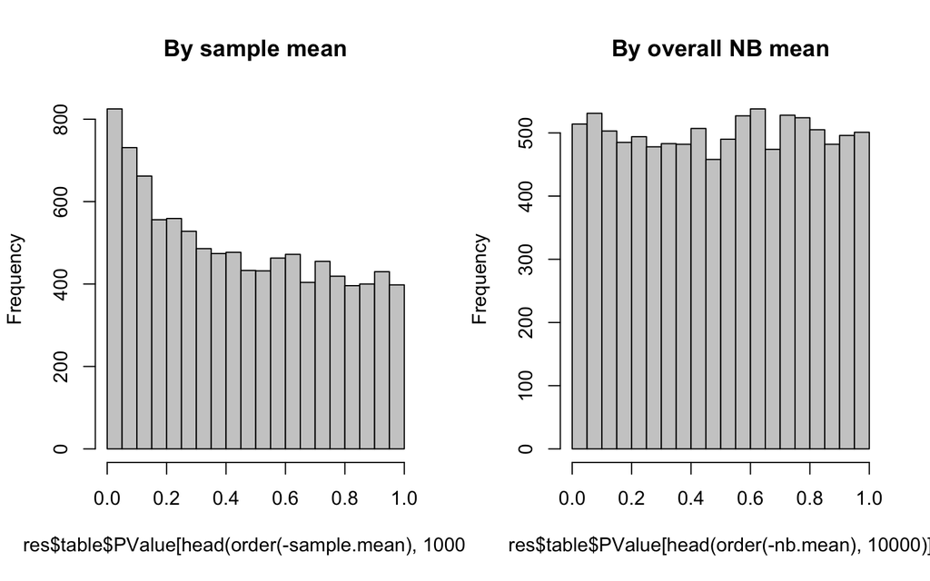

```r
library(edgeR)
y <- matrix(rnbinom(1000000, mu=rep(c(10, 50), each=5), size=10),
    ncol=10, byrow=TRUE)

sample.mean <- rowMeans(y)
offsets <- log(colSums(y))
nb.mean <- mglmOneGroup(y, offset=offsets, dispersion=0.1)

design <- model.matrix(~gl(2,5))
fit <- glmFit(y, design, dispersion=0.1, offset=offsets)
res <- glmLRT(fit)

par(mfrow=c(1,2))
hist(res$table$PValue[head(order(-sample.mean), 10000)],
    main="By sample mean", col="grey80")
hist(res$table$PValue[head(order(-nb.mean), 10000)],
    main="By overall NB mean", col="grey80")
```

The exceptions occur with Poisson-distributed counts or when the offsets are identical. In such cases, the overall NB mean *is* the sample mean, so there is no problem with using one or the other.c

# 3 Logistical concerns

## 3.1 Knowing the dispersion

Strictly speaking, the dispersion needs to be known prior to calculating the overall NB mean. However, filtering usually occurs at the first step of any differential analysis. This means that an appropriate dispersion estimate is not available during calculation of the overall NB mean.

There are several motivations for the current state of affairs. Filtering first improves computational efficiency by skipping work on uninteresting low-abundance features (not negligible when dealing with millions of potential features!); and avoids problems with dispersion estimation at low counts interfering with empirical Bayes (EB) shrinkage. The latter effect has many contributing factors including:

- Discreteness of the dispersion estimates that interfere with estimation of the EB parameters.
- Sharp increases in the dispersions at low abundances, making it difficult to fit a stable trend.
- The dominance of low-abundance features in many datasets, dominating the trend fit, e.g., for span-based algorithms.

Furthermore, it is difficult to obtain a precise dispersion estimate for each feature in genomics datasets with limited replication. An EB-shrunken estimate will probably be necessary, which is better than an arbitrary value but not perfect.

## 3.2 Knowing the normalization factors

Correct calculation of the overall NB mean requires precise GLM offsets. For genomics applications, offsets are most simply defined as the log-library sizes. However, additional scaling normalization may be necessary to account for effects such as composition bias (e.g., TMM normalization in the `calcNormFactors()` function).

Standard workflows perform normalization after filtering due to the detrimental effect of low counts on the former. Discreteness interferes with calculation of quantiles and the high variability of low counts (relative to the mean) degrades the precision of scaling factor estimates. This means that normalization factors (and thus accurate offsets) are not actually available during calculation of the filter statistic.

## 3.3 A more accurate workflow

In theory, a more accurate pre-processing procedure would look like:

1. Apply a very relaxed filter based on the overall NB mean computed with a guess for the dispersion.
2. Estimate the dispersions and normalization factors.
3. Use the estimated dispersions/normalization factors to estimate the overall NB mean among the features retained by the first filter.
4. Re-filter more stringently using the re-estimated overall NB mean.
5. Proceed with the rest of the analysis.

Needless to say, the above approach is rather tedious to implement and the benefits are not obvious. Minor inaccuracies in the dispersion estimates are probably well-tolerated and can be ignored altogether if the offsets are the same across samples. (Vice versa for inaccuracies in the offsets if the dispersion is near zero.) Thus, we recommend simply filtering once and proceeding to the rest of the analysis.

# 4 Considering the filter boundary

In practice, the effect of differences between filtering strategies depends on the density of features at the filter boundary. Consider a $n$-dimensional space in which all features are distributed, where the coordinates of each feature are defined as the values of the observations or counts across all of the $n$ samples in the dataset. The filter boundary refers to a high-dimensional surface in this space which separates the features that are retained from those that are filtered out. If there are few features near the boundary, the use of an inappropriate filter will have little impact on the distribution of the sample variances or test statistics. This is often the case for RNA-seq datasets where the abundances of all genes are spread sparsely across several orders of magnitude. Changes in the shape of the filter boundary at any particular abundance will have little effect on gene retention. In contrast, ChIP-seq datasets are dominated by low-abundance regions containing weak binding sites and/or background enrichment. This results in a high density of features at the boundary, such that differences in filtering are likely to affect retention.

```
## R Under development (unstable) (2018-12-07 r75787)
## Platform: x86_64-apple-darwin15.6.0 (64-bit)
## Running under: OS X El Capitan 10.11.6
##
## Matrix products: default
## BLAS: /Library/Frameworks/R.framework/Versions/3.6/Resources/lib/libRblas.0.dylib
## LAPACK: /Library/Frameworks/R.framework/Versions/3.6/Resources/lib/libRlapack.dylib
##
## locale:
## [1] en_GB.UTF-8/en_GB.UTF-8/en_GB.UTF-8/C/en_GB.UTF-8/en_GB.UTF-8
##
## attached base packages:
## [1] stats     graphics  grDevices utils     datasets  methods   base
##
## other attached packages:
## [1] edgeR_3.19.3     limma_3.33.7     BiocStyle_2.11.0
##
## loaded via a namespace (and not attached):
##  [1] locfit_1.5-9.1     Rcpp_1.0.0         bookdown_0.9
##  [4] lattice_0.20-38    digest_0.6.18      grid_3.6.0
##  [7] magrittr_1.5       evaluate_0.12      stringi_1.2.4
## [10] rmarkdown_1.11     tools_3.6.0        stringr_1.3.1
## [13] xfun_0.4           yaml_2.2.0         compiler_3.6.0
## [16] BiocManager_1.30.4 htmltools_0.3.6    knitr_1.21
```